# Notes on Machine Learning Techniques

Yang Ge

November 13, 2015

```r
library(knitr)
opts_chunk$set(echo = TRUE, cache = TRUE)
library(dplyr)
```

# Lecture 1 Linear Support Vector Machine

## Course Introduction

**Course Design**

- From foundations to techniques

## Large-Margin Separating Hyperplane

**Linear Classification Revisited**

- PLA/pocket: $h(x) = \text{sign}(s)$
  - plausible err = 0/1 (small flipping noise) minimize specially

linear (hyperplane) classifiers:

$h(x) = \text{sign} (w^T x)$

**Which Line Is Best**

- PLA? depending on randomness
- VC bound? whichever you like!
  - $E_{out}(w) \le \underbrace{E_{in}(w)}_{0} + \underbrace{\Omega(\mathcal{H})}_{d_{VC} = d + 1}$
- You? rightmost? Possibly?

**Why Rightmost Hyperplane?**

**Fat Hyperplane**

- robust separating hyperplane: fat
  - far from both sides of examples
- robustness $\equiv$ fatness: distance to closest $x_n$

goal: find fattest separating hyperplane.

**Large-Margin Separating Hyperplane**

- $\underset{w}{\text{max}}$ fatness(w)
- subject to:
  - $w$ classifies every $(x_n, y_n)$ correctly
  - fastness(w) = $\underset{n = 1, \dots, N}{\text{distance}(x_n, w)}$
- fatness: formally called *margin*
- correctness: $y_{n} = \text{sign} (w^T x_{n})$

So we have the following:

- $\underset{w}{\text{max}}$ fatness(w)
- subject to:
  - every $y_{n} w^T x_{n} > 0$
  - margin(w) = $\underset{n = 1, \dots, N}{\text{distance}(x_n, w)}$

goal: find *Large-Margin* *separating* hyperplane.

## Standard Large-Margin Problem

**Distance to Hyperplane: Preliminary**

‘shorten’ $x$ and $w$

- distance needs $w_{0}$ and $(w_1, \dots, w_d)$ differently (to be derived)
- $b = w_0$, $w = [w_1, \dots, x_d]$; $x = [x_1, \dots, x_d]$

**Distance to Hyperplane**

want: distance $(x, b, w)$, with hyperplane $w^T x' + b = 0$

consider $x', x''$ on hyperplane:

1. $w^Tx' = -b$, $w^Tx'' = -b$
2. $w \perp$ hyperplane $w^T (x'' - x') = 0$
3. distance = project $(x - x')$ to $\perp$ hyperplane.

$\text{distance}(x, b, w) = \begin{vmatrix} \frac{w^T}{ \begin{Vmatrix} w \end{Vmatrix} } (x - x') \end{vmatrix} = \frac{1}{ \begin{Vmatrix} w \end{Vmatrix} } \begin{vmatrix} w^T x + b \end{vmatrix}$

**Distance to Separating Hyperplane**

$\text{distance}(x, b, w) = \frac{1}{ \begin{Vmatrix} w \end{Vmatrix} } \begin{vmatrix} w^T x + b \end{vmatrix}$

- separating hyperplane: for every $n$

$y_{n}(w^T x_n + b) > 0$

- distance to separating hyperplane:

$\text{distance}(x, b, w) = \frac{1}{ \begin{Vmatrix} w \end{Vmatrix} } y_n(w^T x + b)$

- In summary:

$\begin{split} \underset{b,w}{\text{max}} &\quad \text{margin}(b, w) \\ \text{subject to} &\quad \text{every } y_{n}(w^T x_n + b) > 0 \\ &\quad \text{margin}(b, w) = \underset{n=1, \dots, N}{min}\frac{1}{ \begin{Vmatrix} w \end{Vmatrix} } y_n (w^T x_n + b) \end{split}$

**Margin of Special Separating Hyperplane**

From above problem and notice the following 2 points:

- $w^Tx + b = 0$ same as $3w^Tx + 3b = 0$: scaling does not matter
- special scaling: only consider separating $(b, w)$ such that

$\underset{n=1, \dots, N}{\text{min}} y_n (w^T x_n + b) = 1 \implies \text{margin}(b, w) = \frac{1}{ \begin{Vmatrix} w \end{Vmatrix}}$

- We have new formula:

$\begin{split} \underset{b,w}{\text{max}} &\quad \frac{1}{ \begin{Vmatrix} w \end{Vmatrix}} \\ \text{subject to} &\quad \text{every } y_{n}(w^T x_n + b) > 0 \\ &\quad \underset{n=1, \dots, N}{\text{min}} y_n (w^T x_n + b) = 1 \end{split}$

- We could further simplify to the following since the 2nd condition is strong than the 1st one:

$\begin{split} \underset{b,w}{\text{max}} &\quad \frac{1}{ \begin{Vmatrix} w \end{Vmatrix}} \\ &\quad \underset{n=1, \dots, N}{\text{min}} y_n (w^T x_n + b) = 1 \end{split}$

**Standard Large-Margin Hyperplane Problem**

- original constraints: $\underset{n=1, \dots, N}{\text{min}} y_n (w^T x_n + b) = 1$
  - want: optimal $(b, w)$ here (inside)
- necessary constraints: $y_n (w^T x_n + b) \ge 1$ for all $n$
- if optimal $(b, w)$ outside, e.g. $y_n (w^T x_n + b) > 1.126$ for all $n$
  - can scale $(b, w)$ to “more optimal” $(\frac{b}{1.126}, \frac{w}{1.126})$ (contradiction!)

We have another new constraints:

$\begin{split} \underset{b,w}{\text{max}} &\quad \frac{1}{ \begin{Vmatrix} w \end{Vmatrix}} \\ \text{subject to} &\quad y_n (w^T x_n + b) \ge 1 \text{ for all } n \end{split}$

final change: $\text{max }\implies \text{min}$, remove $\sqrt{\quad}$

$\begin{split} \underset{b,w}{\text{min}} &\quad \frac{1}{2} w^T w \\ \text{subject to} &\quad y_n (w^T x_n + b) \ge 1 \text{ for all } n \end{split}$

## Support Vector Machine

**Solving a Particular Standard Problem**

- $\underset{b,w}{\text{min}} \frac{1}{2} w^T w$
- subject to:
  - $y_n (w^T x_n + b) \ge 1$ for all $n$

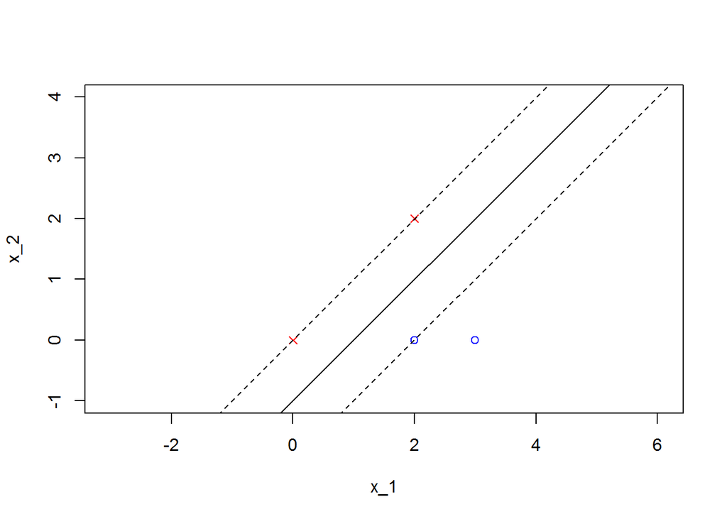

```r
data <- data.frame(x0=c(0, 2, 2, 3), x1=c(0, 2, 0, 0), y=c(-1, -1, 1, 1))
plot(data$x0, data$x1, type = "n", xlim = c(-1, 4), ylim = c(-1, 4), asp = 1, xlab = "x_1", ylab = "x_2")
points(data$x0[1:2], data$x1[1:2], pch = 4, col = "red")
points(data$x0[3:4], data$x1[3:4], pch = 1, col = "blue")
abline(a = -1, b = 1)
abline(a = 0, b = 1, lty = 2)
abline(a = -2, b = 1, lty = 2)
```

- $g_{SVM} = \text{sign}(x_1 - x_2 - 1)$

**Support Vector Machine (SVM)**

- optimal solution: $(w_1 = 1, w_2 = -1, b = -1)$
- $\text{margin}(b, w) = \frac{1}{\begin{Vmatrix}w\end{Vmatrix}} = \frac{1}{\sqrt{2}}$
- examples on boundary: ‘locates’ fattest hyperplane. Other examples: not needed.
- call boundary example *Support Vector*

*Support vector* machine (SVM): learn fattest hyperplanes (with help of support vectors)

**Solving General SVM**

$\begin{split} \underset{b,w}{\text{min}} &\quad \frac{1}{2} w^T w \\ \text{subject to } &\quad y_n (w^T x_n + b) \ge 1 \end{split}$

- not easy manually, of course.
- gradient descent? not easy with constraints
- luckily:
  - (convex) quadratic objective function of $(b, w)$
  - linear constraints of $(b, w)$
- quadratic programming (QP): ‘easy’ optimization problem.

**Quadratic Programming**

$\begin{split} \text{optimal}(b, w) &=? \\ \underset{b,w}{\text{min}} \quad & \frac{1}{2} w^T w \\ \text{subject to } \quad & y_n (w^T x_n + b) \ge 1 \\ & \text{for } n = 1, 2, \dots, N \\ \end{split}$

- Generic form of quadratic programming

$\begin{split} \text{optimal } u \rightarrow & QP(Q, p, A, c) \\ \underset{u}{\text{min}} \quad & \frac{1}{2} u^T Q u + p^T u \\ \text{subject to } \quad & a_m^T u \ge c_m, \\ & \text{for } m = 1, 2, \dots, M \\ \end{split}$

- objective function:
  - $u = \begin{bmatrix} b \\ w \end{bmatrix}$
  - $Q = \begin{bmatrix} 0 & 0^T \\ 0 & I \end{bmatrix}$
  - $p = 0_{d+1}$
- constraints:
  - $a_m = y_n[1, x_n^T]$
  - $c_n = 1$
  - $M = N$
- SVM with general QP solver: easy if you’ve read the manual.

**SVM with QP Solver**

- Linear Hard-Margin SVM Algorithm:
  1. $Q, p, a^T_n, c_n$ as above
  2. $\begin{bmatrix} b \\ w \end{bmatrix} \leftarrow \text{QP}(Q, p, A, c)$
  3. return $b \& w$ as $g_{svm}$
- Hard-Margin: nothing violate ‘fat boundary’
- linear $x_n$
- want non-linear? $z_n = \Phi(x_n)$ - remember?

## Reasons Behind Large-Margin Hyperplane

**Why Large-Margin Hyperplane**

$\begin{split} \underset{b,w}{\text{min}} \quad & \frac{1}{2} w^T w \\ \text{subject to } \quad & y_n (w^T x_n + b) \ge 1 \text{ for all } n \end{split}$

|  | minimize | constraint |
| --- | --- | --- |
| regularization | $E_{in}$ | $w^Tw \le C$ |
| SVM | $w^Tw$ | $E_{in} = 0$ [and more: $y_n(wx_n+b) \ge 1$] |

SVM (Large-Margin hyperplane): ‘weight-decay regularization’ within $E_{in} = 0$

**Large-Margin Restricts Dichotomies**

consider ‘Large-Margin algorithm’ $\mathcal{A}_{\rho}$: either returns $g$ with margin($g$) $\ge \rho$, or 0 otherwise.

- $\mathcal{A}_0$: like PLA $\implies$ shatter ‘general’ 3 inputs
- $\mathcal{A}_{1.126}$: more strict than SVM $\implies$ cannot shatter any 3 inputs

fewer dichotomies $\implies$ smaller VC dim $\implies$ better generalization.

**VC Dimenson of Large-Margin Algorithm**

fewer dichotomies $\implies$ smaller ‘VC dim.’

- considers $d_{VC}(\mathcal{A}_{\rho})$ [data dependent, need more than VC]
- instead of $d_{VC}(\mathcal{H})$ [data independent, covered VC]
- $d_{VC}(\mathcal{A}_{\rho})$ when $\mathcal{X}$ = unit circle in $\mathbb{R}^2$, where $\mathcal{X}$ is the data set.
- $\rho = 0$: just perceptrons ($d_{VC} = 3$)
- $\rho \ge \frac{\sqrt{3}}{2}$: cannot shatter any 3 inputs ($d_{VC} < 3$)
  - some inputs must be of distance $\le \sqrt{3}$

generally, when $\mathcal{X}$ in radius-R hyperball:

$d_{VC}(\mathcal{A}_{\rho}) \le \text{min} (\frac{R^2}{\rho^2}, d) + 1 \le \underbrace{d+1}_{d_{VC}(\text{perceptron})}$

**Benefits of Large-Margin Hyperplanes**

|  | Large-Margin Hyperplanes | Hyperplanes | Hyperplanes + feature transform $\Phi$ |
| --- | --- | --- | --- |
| # of hypothesis | even fewer | not many | many |
| boundary | simple | simple | sophisticated |

- not many: good for $d_{VC}$ and generalization
- sophisticated: good for possibly better $E_{in}$
- a new possiblility: non-linear SVM

|  | Large-Margin Hyperplanes + numerous feature transform $\Phi$ |
| --- | --- |
| # | not many |
| boundary | sophisticated |

## Conclusions

- Large-Margin Separating Hyperplane
  - intuitively more robust against noise
- Standard Large-Margin Problem
  - minimize ‘length of w’ at special separating scale
- Support Vector Machine
  - ‘easy’ via quadratic programming
- Reasons Behind Large-Margin Hyperplane
  - fewer dichotomies and better generalization

# Lecture 2 Dual Support Vector Machine

## Motivation of Dual SVM

**Non-Linear Support Vector Machine Revisited**

$\begin{split} \underset{b,w}{\text{min}} \quad & \frac{1}{2} w^T w \\ \text{subject to } \quad & y_n (w^T \underbrace{z_n}_{\Phi(x_n)} + b) \ge 1 \text{ for all } n \end{split}$

Non-Linear Hard-Margin SVM

1. $Q = \begin{bmatrix} 0 & 0^T_{\tilde{d}} \\ 0_{\tilde{d}} & I_{\tilde{d}} \end{bmatrix}$; $p = 0_{\tilde{d}+1}$; $a_n = y_n[1, z_n^T]$; $c_n = 1$
2. $\begin{bmatrix} b \\ w \end{bmatrix} \leftarrow \text{QP}(Q, p, A, c)$
3. return $b \in \mathbb{R}$ & $w \in \mathbb{R}^{\tilde{d}}$ with $g_{svm}(x) = \text{sign}(w^T \Phi(x) + b)$
- demanded: not many (Large-Margin), but sophisticated boundary (feature transform)
- QP with $\tilde{d}+1$ variables and $N$ constraints - challenging if $\tilde{d}$, or infinite?!

Goal: SVM without dependence on $\tilde{d}$

**TODO: SVM without $\tilde{d}$**

- Original SVM
  - $\tilde{d} + 1$ variables
  - $N$ constraints
- ‘Equivalent’ SVM
  - $N$ variables
  - $N+1$ constraints

Warning: Heavy Math!!!

- introduce some necessary math without rigor to help understand SVM deeper
- ‘claim’ some results if details unnecessary - like how we ‘claimed’ Hoeffding

‘Equivalent’ SVM: based on some dual problem of Original SVM

**Key Tool: Lagrange Multipliers**

| Regularization by Constrained-Minimizing $E_{in}$ | Regularization by Minimizing E_{aug} |
| --- | --- |
| $\underset{w}{\text{min}} E_{in}(w) \text{s.t. } w^Tw \le C$ | $\underset{w}{\text{min}} E_{aug}(w) =E_{in}(w) + \frac{\lambda}{N} w^T w$ |

- $C$ equivalent to some $\lambda \ge 0$ by checking optimality condition

$\nabla E_{in}(w) + \frac{2\lambda}{N} w = 0$

- regularization: view $\lambda$ as given parameter instead of $C$, and solve ‘easily’
- dual SVM: view $\lambda$ as unknown given the constraints, and solve them as variables instead.

how many $\lambda$’s as variables? $N$.

**Starting Point: Constrained to ‘Unconstrained’**

$\begin{split} \underset{b,w}{\text{min}} \quad & \frac{1}{2} w^T w \\ \text{subject to } \quad & y_n (w^T \underbrace{z_n}_{\Phi(x_n)} + b) \ge 1 \text{ for all } n \end{split}$

Lagrange Function: with Lagrange Multipliers $\alpha_n$

$\mathcal{L}(b, w, \alpha) = \underbrace{\frac{1}{2} w^T w}_{\text{objective}} + \sum_{n=1}^{N} \alpha_n \underbrace{(1 - y_n(w^T z_n + b))}_{\text{constraint}}$

Claim

$\text{SVM } \equiv \underset{b,w}{\text{min}} (\underset{\text{all } \alpha_n \ge 0}{\text{max}} \mathcal{L}(b, w, \alpha)) = \underset{b,w}{\text{min}} ( \infty \text{ if violate }; \frac{1}{2} w^T w \text{ if feasible})$

- any violating $(b, w)$: $\underset{\text{all } \alpha_n \ge 0}{\text{max}} (\square + \sum_n \alpha_n (\text{some positive})) \rightarrow \infty$
- any feasible $(b, w)$: $\underset{\text{all } \alpha_n \ge 0}{\text{max}} (\square + \sum_n \alpha_n (\text{al non-positive})) = \square$

Constraint now hidden in $max$.

## Lagrange Dual SVM

**Lagrange Dual Problem**

for any fixed $\alpha'$ with all $\alpha_n' \ge 0$,

$\underset{b,w}{\text{min}} (\underset{\text{all } \alpha_n \ge 0}{\text{max}} \mathcal{L}(b, w, \alpha)) \ge \underset{b,w}{\text{min}} \mathcal{L}(b, w, \alpha'))$

because $\text{max} \ge \text{any}$.

for best $\alpha' \ge 0$ on RHS,

$\underset{b,w}{\text{min}} (\underset{\text{all } \alpha_n \ge 0}{\text{max}} \mathcal{L}(b, w, \alpha)) \ge \underbrace{ \underset{\text{all } \alpha_n \ge 0}{\text{max}} \underset{b,w}{\text{min}} \mathcal{L}(b, w, \alpha')) }_{\text{Lagrange dual problem}}$

because best is one of any.

If we solve the dual problem, we get a lower bound of the primal problem.

- Lagrange dual problem:
  - outer maximization of $\alpha$ on lower bound of original problem

**Strong Duality of Quadratic Programming**

$\underbrace{ \underset{b,w}{\text{min}} (\underset{\text{all } \alpha_n \ge 0}{\text{max}} \mathcal{L}(b, w, \alpha)) }_{\text{equiv. to original (primal) SVM}} = \underbrace{ \underset{\text{all } \alpha_n \ge 0}{\text{max}} \underset{b,w}{\text{min}} \mathcal{L}(b, w, \alpha')) }_{\text{Lagrange dual problem}}$

- $ge$: weak duality
- $=$: strong duality, true for QP if
  - convex primal
  - feasible primal (true if $\Phi$-separable)
  - linear constraints
- called constraint qualification

exists primal-dual optimal solution $(b, w, \alpha)$ for both sides.

**Solving Lagrange Dual: Simplification (1/2)**

$\underset{\text{all } \alpha_n \ge 0}{\text{max}} \left( \underset{b,w}{\text{min}} \underbrace{ \frac{1}{2} w^Tw + \sum_{n=1}^{N} \alpha_n (1 - y_n (w^Tz_n + b)) }_{\mathcal{L}(b, w, \alpha)} \right)$

- inner problem ‘Unconstrained’, at optimal:
  - $\frac{\partial \mathcal{L}(b, w, \alpha)}{\partial b} = 0 = -\sum_{n=1}^{N} \alpha_n y_{n}$
- no loss of optimality if solving with constraint $\sum_{n=1}^{N} \alpha_n y_{n} = 0$

Then we can remove $b$.

$\underset{\text{all } \alpha_n \ge 0, \sum y_{n} \alpha_{n} = 0}{\text{max}} \left( \underset{b,w}{\text{min}} \frac{1}{2} w^Tw + \sum_{n=1}^{N} \alpha_n (1 - y_n (w^Tz_n)) \right)$

**Solving Lagrange Dual: Simplification (2/2)**

$\underset{\text{all } \alpha_n \ge 0, \sum y_{n} \alpha_{n} = 0}{\text{max}} \left( \underset{b,w}{\text{min}} \frac{1}{2} w^Tw + \sum_{n=1}^{N} \alpha_n (1 - y_n (w^Tz_n)) \right)$

- inner problem ‘Unconstrained’, at optimal:
  - $\frac{\partial \mathcal{L}(b, w, \alpha)}{\partial w_i} = 0 = w_i -\sum_{n=1}^{N} \alpha_n y_{n} z_{n,i}$
- no loss of optimality if solving with constraint $w = \sum_{n=1}^{N} \alpha_n y_{n} z_n$

$\begin{split} & \underset{\text{all } \alpha_n \ge 0, \sum y_{n} \alpha_{n} = 0, w = \sum \alpha_n y_{n} z_n }{\text{max}} \left( \underset{b,w}{\text{min}} \frac{1}{2} w^Tw + \sum_{n=1}^{N} \alpha_n - w^T w \right) \\ \iff & \underset{\text{all } \alpha_n \ge 0, \sum y_{n} \alpha_{n} = 0, w = \sum \alpha_n y_{n} z_n }{\text{max}} -\frac{1}{2} \begin{Vmatrix} \sum_{n=1}^{N} \alpha_n y_{n} z_n \end{Vmatrix} + \sum_{n=1}^{N} \alpha_n \end{split}$

**KTT Optimality Conditions**

$\underset{\text{all } \alpha_n \ge 0, \sum y_{n} \alpha_{n} = 0, w = \sum \alpha_n y_{n} z_n }{\text{max}} -\frac{1}{2} \begin{Vmatrix} \sum_{n=1}^{N} \alpha_n y_{n} z_n \end{Vmatrix} + \sum_{n=1}^{N} \alpha_n$

- If primal-dual optimal $(b, w, \alpha)$
  - primal feasible: $y_{n} (w^T z_n + b) \ge 1$
  - dual feasible: $\alpha_n \ge 0$
  - dual-inner optimal: $\sum y_n \alpha_n = 0; w = \sum \alpha_n y_n z_n$
  - primal-inner optimal (at optimal all ‘Lagrange term’ disappear): $\alpha_n (1 - y_n (w^T z_n + b)) = 0$. which is called **complimentary slackness**

called Karush-Kuhn-Tucker (KKT) conditions, necessary for optimality [& sufficient here].

Will use KKT to ‘solve’ $(b, w)$ from optimal $\alpha$.

## Solving Dual SVM

**Dual Formulation of Support Vector Machine**

$\underset{\text{all } \alpha_n \ge 0, \sum y_{n} \alpha_{n} = 0, w = \sum \alpha_n y_{n} z_n }{\text{max}} -\frac{1}{2} \begin{Vmatrix} \sum_{n=1}^{N} \alpha_n y_{n} z_n \end{Vmatrix} + \sum_{n=1}^{N} \alpha_n$

Standard Hard-Margin SVM dual

$\begin{split} \underset{\alpha}{\text{min}} & \frac{1}{2} \sum_{n=1}^{N} \sum_{m=1}^{N} \alpha_n \alpha_m y_n y_m z_n^T z_m - \sum_{n=1}^{N} \alpha_n \\ \text{subject to } & \sum_{n=1}^{N} y_n \alpha_n = 0 \\ & \alpha_n \ge 0, \text{ for } n = 1, 2, \dots, N \end{split}$

- (convex) QP of $N$ variables & $N+1$ constraints, as promised
- How to solve? yeah! we know QP! :)

**Dual SVM with QP Solver**

$\begin{split} \text{optimal } \alpha \leftarrow & QP(Q, p, A, c) \\ \underset{u}{\text{min}} \quad & \frac{1}{2} \alpha^T Q \alpha + p^T u \\ \text{subject to } \quad & a_m^T \alpha \ge c_m, \\ & \text{for } m = 1, 2, \dots, M \\ \end{split}$

$\begin{split} q_{n,m} \quad & = y_n y_m z_n^T z_m \\ p \quad & = -1_N \\ a_{\ge} = y \quad &; c_{\ge} = 0; \\ a_{\le} = -y \quad &; c_{\le} = 0; \\ a_n^T = n \text{-th unit direction} \quad &; c_n = 0 \end{split}$

Note: many solvers treat equality ($a_{\ge}, a_{\le}$) & bound constraints ($a_n$) specially for numerical stability.

**Dual SVM with Special QP Solver**

- $q_{n,m} = y_n y_m z_n^T z_m$, often non-zero, dense.
- if $N = 30000$, dense $Q_d$ ($N$ by $N$ symmetric) takes > 3G RAM
- need special solver for
  - not storing whole $Q_D$.
  - utilizing special constraints properly.
- to scale up to large $N$.
- usually better to use special solver in practice.

**optimal $(b, w)$**

KKT conditions

- if primal-dual optimal $(b, w, \alpha)$
  - primal feasible: $y_{n} (w^T z_n + b) \ge 1$
  - dual feasible: $\alpha_n \ge 0$
  - dual-inner optimal: $\sum y_n \alpha_n = 0; w = \sum \alpha_n y_n z_n$
  - primal-inner optimal (at optimal all ‘Lagrange term’ disappear): $\alpha_n (1 - y_n (w^T z_n + b)) = 0$. (**complimentary slackness**)
- optimal $\alpha \implies$ optimal $w$? easy above!
- optimal $\alpha \implies$ optimal $b$? a range from primal feasible & equality from complimentary slackness if one $\alpha_n > 0 \implies b = y_n - w^T z_n$

complimentary slackness: $\alpha_n > 0 \implies$ on fat boundary (SV!)

## Messages behind Dual SVM

**Support Vectors Revisited**

- on boundary: ‘locates’ fattest hyperplane; others: not needed.
- examples with $\alpha_n > 0$: on boundary
- call $\alpha_n > 0$ examples $(z_n, y_n)$ support vectors
- SV (positive $\alpha_n$) $\subseteq$ SV candidates (on boundary)
- only SV needed to compute $w: w = \sum_{n=1}^{N} \alpha_n y_n z_n = \sum_{SV} \alpha_n y_n z_n$
- only SV needed to compute $b: b = y_n - w^T z_n$ with any SV $(z_n, y_n)$

SVM: learn fattest hyperplane by identifying support vectors with dual optimal solution.

**Representation of Fattest Hyperplane**

| SVM | PLA |
| --- | --- |
| $w_{SVM}= \sum_{n=1}^{N} \alpha_n y_n z_n$ | $w_{PLA} = \sum_{n=1}^{N} \beta_n y_n z_n$ |
| $\alpha_n$ from dual solution | $\beta_n$ by # mistake corrections |

$w =$ linear combination of $y_n z_n$

- also true for GD/SGD-based LogReg/LinReg when $w_0 = 0$
- call $w$ ‘represented’ by data

哲学上来说：我们想如何表现 $w$:

- SVM: represent $w$ by SVs only.

**Summary: Two Forms of Hard-Margin SVM**

[output not shown]

Both eventually result in optimal $(b, w)$ for fattest hyperplane

$g_{SVM}(x) = \text{sign} (w^T \Phi(x) + b)$

**Are We Done Yet?**

$\begin{split} \underset{\alpha}{\text{min}} \quad & \frac{1}{2} \alpha^T Q_D \alpha - 1^T \alpha \\ \text{subject to } \quad & y^T \alpha = 0 ;\\ & \alpha_n \ge 0 \text{ for } n = 1, \dots, N \end{split}$

- $N$ variables, $N+1$ simple constraints: no dependence on $\tilde{d}$?
- $q_{n,m} = y_n y_m z_n^T z_m$: inner product in $\mathbb{R}^{\tilde{d}}$
  - $O(\tilde{d})$ via naive computation!

no dependence only if avoiding naive computation! (next lecture :))

## Conclusions

- Motivation of Dual SVM
  - want to remove dependence $\tilde{d}$
- Lagrange Dual SVM
  - KKT conditions link primal/dual
- Solving Dual SVM
  - another QP, better solved with special solver
- Messages behind Dual SVM
  - SVs represent fattest hyperplane

# Lecture 3 Kernel Support Vector Machine

## Kernel Trick

**Dual SVM Revisited**

goal: SVM without dependence on $\tilde{d}$

half way done:

$\begin{split} \underset{\alpha}{\text{min}} \quad & \frac{1}{2} \alpha^T Q_D \alpha - 1^T \alpha \\ \text{subject to } \quad & y^T \alpha = 0 ;\\ & \alpha_n \ge 0 \text{ for } n = 1, \dots, N \end{split}$

- $q_{n,m} = y_n y_m z_n^T z_m$: inner product in $\mathbb{R}^{\tilde{d}}$
- need: $z_n^T z_m = \Phi(x_n)^T \Phi(x_m)$ calculated faster than $O(\tilde{d})$
  - 先做转换，再做内积。Assume 10000 dimension, 10000 cost to to the transform, 10000 cost to do the inner product.
  - 可以合起来偷吃步吗？

**Fast Inner Product for $\Phi_2$**

- 2nd order polynomial transform
  - $\Phi_2(x) = (1, x_1, x_2, \dots, x_d, x_1^2, x_1x_2, \dots, x_1x_d, x_2x_1, x_2^2, \dots, x_2x_d, \dots, x_d^2)$
  - Include both $x_1x_2$ & $x_2x_1$ for simplicity.

$\begin{split} \Phi_2(x)^T \Phi_2(x') \quad & = 1 + \sum_{i=1}^{d} x_ix_i' + \sum_{i=1}^{d} \sum_{j=1}^{d} x_ix_jx_i'x_j' \\ \quad & = 1 + \sum_{i=1}^{d} x_ix_i' + \sum_{i=1}^{d} x_ix_i' \sum_{j=1}^{d} x_jx_j' \\ \quad & = 1 + x^Tx' + (x^Tx')(x^Tx') \end{split}$

- For $\Phi_2$, transform + inner product can be carefully done in $O(d)$ instead of $O(d^2)$

**Kernel: Transform + Inner Product**

- transform $\Phi \iff$ Kernel function: $K_{\Phi}(x, x') \equiv \Phi(x)^T \Phi(x')$
- $\Phi_2 \iff K_{\Phi^2}(x, x') = 1 + x^Tx' + (x^Tx')^2$
- quadratic coefficient $q_{n,m} = y_n y_m z_n^T z_m = y_ny_m K(x_n, x_m)$
- optimal bias $b$? From SV($x_s$, $y_s$)

$b = y_s - w^T z_s = y_s - (\sum_{i=1}^{N} \alpha_n y_n z_n)^T z_s = y_s - \sum_{i=1}^{N} ( \alpha_n y_n K(x_n, x_s))$

- optimal hypothesis $g_{SVM}$: for test input x,

$g_{SVM} = \text{sign} (w^T \Phi(x) + b) = \text{sign} (\sum_{n=1}^{N} \alpha_n y_n K(x_n, x) + b)$

没有任何地方需要在$z$空间中进行。

Kernel Trick: plug in efficient kernel function to avoid dependence on $\tilde{d}$

**Kernel SVM with QP**

| Kernel Hard-Margin SVM Algorithm |  |
| --- | --- |
| 1. $q_{n,m} = y_n y_m z_n^T z_m$; $p = -1_N$; $(A, c)$ for equ./bound constraints |  |
| 2. $\alpha \leftarrow QP(Q_D, p, A, c)$ |  |
| 3. $b \leftarrow (y_s - \sum_{i=1}^{N} ( \alpha_n y_n K(x_n, x_s)))$ with SV $(x_s, y_s)$ |  |
| 4. return SVs and their $\alpha_n$ as well as $b$ such that for new $x$, |  |
| $g_{SVM} = \text{sign} (\sum_{n=1}^{N} \alpha_n y_n K(x_n, x) + b)$ |  |

- 1: time complexity $O(N^2) \cdot$ (kernel evaluation)
- 2: QP with $N$ variables and $N+1$ constraints
- 3 and 4: time complexity $O(\# SV) \cdot$ (kernel evaluation)

Kernel SVM: use computational shortcut to avoid $\tilde{d}$ & predict with SV only.

## Polynomial Kernel

**General Poly-2 Kernel**

$\begin{split} \Phi_2(x) = (1, x_1, \dots, x_d, x_1^2, \dots, x_d^2) \quad & \iff K_{\Phi_2}(x, x') = 1 + x^Tx' + (x^Tx')^2 \\ \Phi_2(x) = (1, \sqrt{2}x_1, \dots, \sqrt{2} x_d, x_1^2, \dots, x_d^2) \quad & \iff K_{\Phi_2}(x, x') = 1 + 2x^Tx' + (x^Tx')^2 \\ \Phi_2(x) = (1, \sqrt{2\gamma}x_1, \dots, \sqrt{2\gamma} x_d, x_1^2, \dots, x_d^2) \quad & \iff K_{\Phi_2}(x, x') = 1 + 2\gamma x^Tx' + (x^Tx')^2 \\ \end{split}$

$K_2(x, x') = (1 + \gamma x^Tx')^2 \text{ with } \gamma > 0$

- $K_2$: somewhat ‘easier’ to calculate than $K_{\Phi_2}$
- $\Phi_2$ and $\\Phi_2$: equivalent power, different inner product $\implies$ different geometry.
  - 不同内积代表不同距离，不同的距离有不同的几何特性，算出来的margin就不一样。
  - 就算在同样的空间，也会得到不同的边界。
- $K_2$ commonly used.

**Poly-2 Kernels in Action**

- $g_{SVM}$ different, SVs different.
  - ‘hard’ to say which is better before learning.
- change of kernel $\iff$ change of margin definition

need selecting $K$, just like selecting $\Phi$.

**General Polynomial Kernel**

$\begin{split} K_2(x, x') \quad & = (\zeta + \gamma x^Tx')^2 \text{ with } \gamma > 0, \zeta \ge 0 \\ K_3(x, x') \quad & = (\zeta + \gamma x^Tx')^3 \text{ with } \gamma > 0, \zeta \ge 0 \\ K_Q(x, x') \quad & = (\zeta + \gamma x^Tx')^Q \text{ with } \gamma > 0, \zeta \ge 0 \end{split}$

- embeds $\Phi_Q$ specially with parameters
- allows computing Large-Margin polynomial classification without dependence on $\tilde{d}$
  - Will 10th order overfit? Probably, but the bottom line is that you still has large margin to help you to harness the complexity.
- SVM + Polynomial Kernel: Polynomial SVM

**Special Case Linear Kernel**

$K_1(x, x') = (0 + 1 \dot x^T x)^1$

- $K_1$: just usual inner product, called linear kernel
- ‘even easier’: can be solved (often in primal form) efficiently.

linear first, remember? :)

## Gaussian Kernel

**Kernel of Infinite Dimensional Transform**

Infinite dimensional $\Phi(x)$? Yes, if $K(x, x')$ efficiently computable!

$\begin{split} \text{when } x = (x), K (x, x') \quad &= \quad \text{exp}(-(x-x')^2) \\ \quad &= \quad \text{exp}(-(x)^2) \text{exp}(-(x')^2) \text{exp}(2xx') \\ \quad &= \quad \text{exp}(-(x)^2) \text{exp}(-(x')^2) \left( \sum_{i=0}^{\infty} \frac{(2xx')^i}{i!}\right) \\ \quad &= \quad \sum_{i=0}^{\infty} \left( \text{exp}(-(x)^2) \text{exp}(-(x')^2) \sqrt{\frac{2^i}{i!}} \sqrt{\frac{2^i}{i!}} (x)^i (x')^i \right) \\ \quad &= \quad \Phi(x)^T \Phi(x') \end{split}$

with infinite dimensional $\Phi(x) = \text{exp}(-x^2) \dot (1, \sqrt{\frac{2^1}{1!}}, \sqrt{\frac{2^2}{2!}}, \dots)$

more generally, Gaussian kernel $K(x, x') = \text{exp}(-\gamma \begin{Vmatrix} x-x' \end{Vmatrix}^2 )$ with $\gamma > 0$

**Hypothesis of Gaussian SVM**

$\begin{split} g_{SVM} &= (\text{sign} \sum_{SV} \alpha_n y_n K(x_n, x) + b) \\ &= (\text{sign} \sum_{SV} \alpha_n y_n \text{exp}(-\gamma \begin{Vmatrix} x - x_n \end{Vmatrix}^2) + b) \\ \end{split}$

- linear combination of Gaussian centered at SVs $x_n$
- also called Radial Basis Function (RBF) kernel

Gaussian SVM: find $\alpha_n$ to combine Gaussian centered at $x_n$ & achieve large margin in infinite-dim. space

**Support Vector Mechanism**

[output not shown]

- transformed vector $z = \Phi(x) \implies$ efficient kernel $K(x, x')$
- store optimal $w \implies$ store a few SVs and $\alpha_n$

new possiblility by Gaussian SVM: infinite-dimensional linear classification, with generalization ‘guarded by’ Large-Margin :)

**Gaussian SVM in Action**

- large $\gamma \implies$ sharp Gaussian $\implies$ ‘overfit’
- Warning: SVM can still overfit :(

Gaussian SVM: need careful selection of $\gamma$.

## Comparison of Kernels

**Linear Kernel: Cons and Pros**

$K(x, x') = x^T x$

| Cons | Pros |
| --- | --- |
| restricted - not always separable?! | fast - with special QP solver in primal |
|  | safe - linear first, remember |
|  | very explainable - $w$ and SVs say something |

Linear kernel: an important basic tool.

**Polynomial Kernel: Cons and Pros**

$K(x, x') = (\zeta + \gamma x^T x')^Q$

| Cons | Pros |
| --- | --- |
| numerical difficulty for large $Q$: | less restricted than linear |
| $\|\zeta + \gamma x^Tx'\| < 1: K \rightarrow 0$ | strong physical control - ‘knows’ degree Q |
| $\|\zeta + \gamma x^Tx'\| > 1: K \rightarrow big$ |  |
| three parameters $(\gamma, \zeta, Q)$ - more difficult to select |  |

polynomial kernel: perhaps small-Q only. 当我们心里想好 $Q$ 的时候.

sometimes efficiently done by linear on $\Phi_Q(x)$

**Gaussian Kernel: Cons and Pros**

$K(x, x') = \text{exp}(-\gamma \begin{Vmatrix} x - x' \end{Vmatrix}^2)$

| Cons | Pros |
| --- | --- |
| mysterious - no $w$ | more powerful than linear/poly |
| slower than linear | bounded - less numerical difficult than poly |
| too powerful! | one parameter only - easier to select than poly |

Gaussian kernel: one of most popular but shall be used with care.

**Other Valid Kernels**

- kernel represents special similarity: $\Phi(x)^T \Phi(x')$
- any similarity $\implies$ valid kernel? not really
- necessary and sufficient conditions for valid kernel: Mercer’s condition
  - symmetric
  - let $k_{ij} = K(x_i, x_j)$, the matrix $K = ZZ^T$ must always be positive semi-definite

define your own kernel: possible, but hard.

## Conclusions

- Kernel Trick
  - kernel as shortcut of transform + inner product
- Polynomial Kernel
  - embeds specially-scaled polynomial transform
- Gaussian Kernel
  - embeds infinite dimensional transform
- Comparison of Kernels
  - linear for efficiency or Gaussian for power

# Lecture 4 Soft-Margin Support Vector Machine

## Motivation and Primal Problem

**Cons of Hard-Margin SVM**

recall: SVM can still overfit :(

If always insisting on separable ($\implies$ shatter), have power to overfit to noise.

**Give Up on Some Examples**

want: give up on some noisy examples

| pocket | Hard-Margin SVM |
| --- | --- |
| $\underset{b,w}{\text{min}} \sum_{n=1}^{N} [y_n \ne \text{sign} (w^Tz_n + b)]$ | $\underset{b,w}{\text{min}} \frac{1}{2} w^T w$ |
|  | s.t. $y_n (w^T z_n + b) \ge 1$ for all $n$ |

Combination:

$\begin{split} \underset{b,w}{\text{min}} \quad & \frac{1}{2} w^T w + C \dot \sum_{n=1}^{N} [y_n \ne \text{sign} (w^Tz_n + b)] \\ \text{s.t.} \quad & y_n (w^T z_n + b) \ge 1 \text{ for correct } n \\ & y_n (w^T z_n + b) \ge -\infty \text{ for incorrect } n \end{split}$

$C$: trade-off of large margin & noise tolerance

**Soft-Margin SVM (1/2)**

$\begin{split} \underset{b,w}{\text{min}} \quad & \frac{1}{2} w^T w + C \dot \sum_{n=1}^{N} [ y_n \ne \text{sign} (w^Tz_n + b) ] \\ \text{s.t.} \quad & y_n (w^T z_n + b) \ge 1 - \infty \dot [ y_n \ne \text{sign} (w^Tz_n + b) ] \end{split}$

- $[\dot]$: non-linear, not QP anymore :(
  - what about dual? kernel?
- cannot distinguish small error (slightly away from fat boundary)
  - large error (far away from fat boundary)
- record ‘margin violation’ by $\xi_n$ - linear constraints
- penalize with margin violation instead of error count - quadratic objective

$\begin{split} \underset{b,w}{\text{min}} \quad & \frac{1}{2} w^T w + C \dot \sum_{n=1}^{N} \xi_n \\ \text{s.t.} \quad & y_n (w^T z_n + b) \ge 1 - \xi_n \text{ and } \xi_n \ge 0 \text{ for all } n \end{split}$

**Soft-Margin SVM (1/2)**

- record ‘margin violation’ by $\xi_n$
- penalize with margin violation instead of error count

$\begin{split} \underset{b,w,\xi}{\text{min}} \quad & \frac{1}{2} w^T w + C \dot \sum_{n=1}^{N} \xi_n \\ \text{s.t.} \quad & y_n (w^T z_n + b) \ge 1 - \xi_n \text{ and } \xi_n \ge 0 \text{ for all } n \end{split}$

- parameter $C$: trade-off of Large-Margin and margin violation
  - large $C$: want less margin violation
  - small $C$: want large margin
- QP of $\tilde{d} + 1 + N$ variables, $2N$ constraints

next: remove dependence on $\tilde{d}$ by Soft-Margin SVM primal $\implies$ dual?

## Dual Problem

**Lagrange Dual**

Primal:

$\begin{split} \underset{b,w,\xi}{\text{min}} \quad & \frac{1}{2} w^T w + C \dot \sum_{n=1}^{N} \xi_n \\ \text{s.t.} \quad & y_n (w^T z_n + b) \ge 1 - \xi_n \text{ and } \xi_n \ge 0 \text{ for all } n \end{split}$

Lagrange function with Lagrange multipliers $\alpha_n$ and $\beta_n$

$\begin{split} \mathcal{L}(b, w, \xi, \alpha, \beta) = & \frac{1}{2} w^T w + C \dot \sum_{n=1}^{N} \xi_n \\ & + \sum_{n=1}^{N} \alpha_n \dot (1 - \xi_n - y_n (w^T z_n + b) ) + \sum_{n=1}^{N} \beta_n \dot (-\xi_n) \end{split}$

want: Lagrange dual

$\underset{\alpha_n \ge 0, \beta_n \ge 0}{\text{max}} ( \underset{b, w, \xi}{\text{min}} \mathcal{L}(b, w, \xi, \alpha, \beta) )$

**Simplify $\xi_n$ and $\beta_n$**

$\begin{split} \underset{\alpha_n \ge 0, \beta_n \ge 0}{\text{max}} ( \underset{b, w, \xi}{\text{min}} & \frac{1}{2} w^T w + C \dot \sum_{n=1}^{N} \xi_n \\ & + \sum_{n=1}^{N} \alpha_n \dot (1 - \xi_n - y_n (w^T z_n + b) ) + \sum_{n=1}^{N} \beta_n \dot (-\xi_n) ) \end{split}$

- $\frac{\partial \mathcal{L}}{\partial \xi_n} = 0 = C - \alpha_n - \beta_n$
- no loss of optimality if solving with implicit constraint $\beta_n = C - \alpha_n$ and explicit constraint $0 \le \alpha_n \le C$

## Messages behind Soft-Margin SVM

## Conclusions

- Motivation and Primal Problem
- Dual Problem
- Messages behind Soft-Margin SVM
- Model Selection